# Checkpoint 5

Gunnar Goeden & Brett Graham

11/30/2017

## Progress Made

Objective: Identify potential research questions and further develop and analyze 2-3 Bayesian models for each research question.

Summary: Going into this checkpoint, we had a pre-determined goal or research question that we wanted to address, so we spent our time on this checkpoint developing simple models to address this question, and worked on ways to improve them. Our ultimate research question is: Can we accurately predict the scores of NFL games based on a model which incorporates an offensive and deffensive ability score, which will update as data is recieved from previous games. For this checkpoint, we developed 3 simple models, each building off of the next to learn what our final model will look like. Simple model 1 is a basic Bayesian regression model using a Normal distribution to determine the teams score based on the teams offensive avg rush yards per attempt and avg pass yards per attempt. Simple model 2 builds off of this idea, but uses a Poisson Distribution so we do not have any negative scores. Simple model 3 we did a Poisson Dist with a logged normal structure. Conducting some research, we found literature to suggest that this is the structure we may want to use going forward. Our next steps are to finalize a two-way data matrix, which will allow us to use offensive and defensive scores, and incorporate both into our prediction model. We will also continue to fine-tune our priors for more accurate results.

## Work Distribution

Both of us spent time thinking and discussing what models we wanted to use, defining our variables, and brainstorming how we want to construct these models (both simple and going forward). Aside from this collaborative work, Brett worked on developing the two-way data matrix and forming the offensive and defensive score variables, while Gunnar constructed the simple models in rjags, and created visual plots to analyze progress results.

## Coding & Models

```
## Linked to JAGS 4.1.0
```

```
## Loaded modules: basemod,bugs
```

```
## [1] 58
```

```r
game_stats_2016 <- createDataframe(2016)
data_2016 <- simplify(game_stats_2016)
```

```
## extract_numeric() is deprecated: please use readr::parse_number() instead
```

### First model to predict points scored by a team using their rush yards/att and pass yards/att in the given game

```r
#PLoting a simple Bayesian regression model using avg rush yds/att and avg pass yds/att

simple1 <- "model{
  #Data
  for(i in 1:length(y)) {
        y[i] ~ dnorm(mu[i], tau)
        mu[i] <- b0+b1*x[i]+b2*w[i]

   }

  #Priors
  b0 ~ dnorm(0,1/10)
  b1 ~ dnorm(1,1/10)
  b2 ~ dnorm(1,1/10)
  tau ~ dgamma(1,1/10)


}"


simple1_jags <- jags.model(textConnection(simple1),
                    data= list(y=data_2016$`Home_Points`, x=data_2016$`Home_Avg Rush Gain`, w=data_2016$`Home_Pass Gain/Att`),
                    inits=list(.RNG.name="base::Wichmann-Hill", .RNG.seed=1989))
simple1_sim <- coda.samples(simple1_jags, variable.names=c("b0","b1","b2","tau"), n.iter=10000)

simple1_sample <- data.frame(step=1:10000, simple1_sim[[1]])
head(simple1_sample)
```

```
##   step        b0        b1       b2        tau
## 1    1 13.085797 1.0313046 1.094878 0.01333623
## 2    2 12.385282 0.9600455 1.212951 0.01680806
## 3    3 11.575491 1.0774490 1.203568 0.01393378
## 4    4 10.938510 1.2029671 1.269375 0.01642020
## 5    5  9.326419 1.4901473 1.315008 0.01537721
## 6    6  9.596443 1.3550147 1.459950 0.01395360
```

```r
summary(simple1_sim)
```

[output not shown]

[figure not shown]

```r
plot(simple1_sim)
```

```r
set.seed(1000)
predictsimple1 <- function(x,w){
  rnorm(10000, -1.78594 + 1.31796*x + 2.89480*w, 0.01842^{-1})
}

head(predictsimple1(4,8))
```

```
## [1]   2.443526 -38.820226  28.876999  61.355940 -16.056805   5.716542
```

```r
mean(predictsimple1(4,8))
```

```
## [1] 26.44888
```

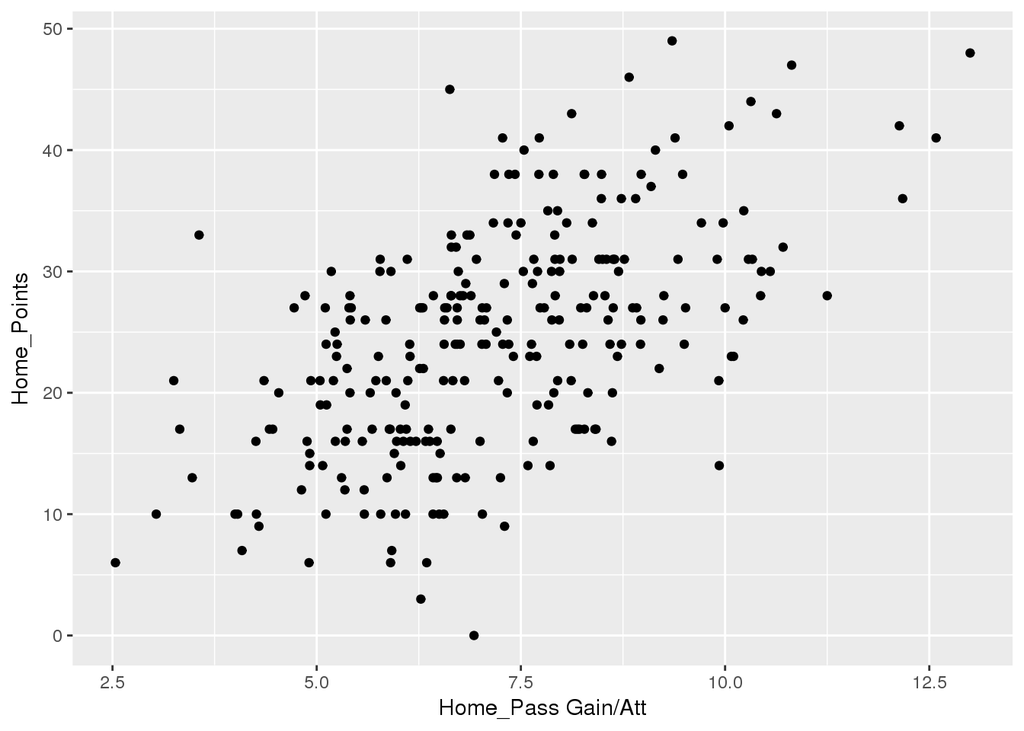

```r
ggplot(data_2016, aes(x=`Home_Pass Gain/Att`,y=`Home_Points`)) +
 geom_point()
```

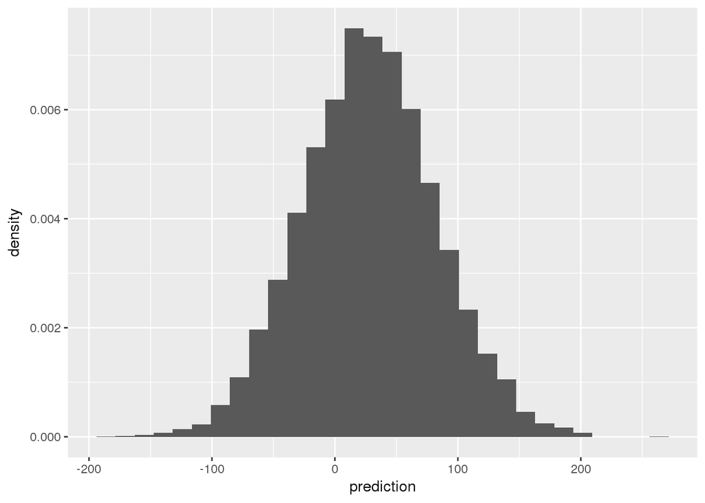

```r
simple_predict = data.frame(predictsimple1(4,8))
colnames(simple_predict)[1]<- "prediction"

ggplot(simple_predict, aes(x=prediction)) + geom_histogram(aes(y=..density..))
```

## Second model to predict points scored by a team using their rush yards/att and pass yards/att in the given game. Adjustment to Pois dist for non-negative points

```r
#PLoting a simple Bayesian regression model using avg rush yds/att and avg pass yds/att

simple2 <- "model{
  #Data
  for(i in 1:length(y)) {
        y[i] ~ dpois(lam[i])
        lam[i] ~ dnorm(mu[i],tau)
         mu[i] <- b0+b1*x[i]+b2*w[i]

   }

  #Priors
  b0 ~ dnorm(0,1/10)
  b1 ~ dnorm(1,1/10)
  b2 ~ dnorm(1,1/10)
  tau ~ dgamma(1,1/10)


}"


simple2_jags <- jags.model(textConnection(simple2),
                    data= list(y=data_2016$`Home_Points`, x=data_2016$`Home_Avg Rush Gain`, w=data_2016$`Home_Pass Gain/Att`),
                    inits=list(.RNG.name="base::Wichmann-Hill", .RNG.seed=1989))
simple2_sim <- coda.samples(simple2_jags, variable.names=c("b0","b1","b2","tau"), n.iter=10000)

simple2_sample <- data.frame(step=1:10000, simple2_sim[[1]])
head(simple2_sample)
```

```
##   step          b0       b1       b2        tau
## 1    1  1.07092869 1.246381 2.555305 0.03196087
## 2    2  0.58875594 1.266304 2.656852 0.02882658
## 3    3  0.08568309 1.093687 2.688464 0.02356498
## 4    4  0.82125701 1.187169 2.684883 0.02736412
## 5    5 -0.53903013 1.479568 2.674187 0.03230269
## 6    6 -0.83593749 1.570432 2.712152 0.02721924
```

```r
summary(simple2_sim)
```

```
##
## Iterations = 1001:11000
## Thinning interval = 1
## Number of chains = 1
## Sample size per chain = 10000
##
## 1. Empirical mean and standard deviation for each variable,
##    plus standard error of the mean:
##
##         Mean       SD  Naive SE Time-series SE
## b0  -1.72284 1.809429 1.809e-02      0.1293393
## b1   1.28778 0.307228 3.072e-03      0.0157956
## b2   2.90273 0.231058 2.311e-03      0.0130633
## tau  0.03027 0.004172 4.172e-05      0.0000969
##
## 2. Quantiles for each variable:
##
##         2.5%      25%    50%      75%   97.5%
## b0  -5.25961 -2.98208 -1.671 -0.46168 1.79293
## b1   0.70286  1.07374  1.278  1.49960 1.89915
## b2   2.45606  2.74309  2.902  3.06546 3.35455
## tau  0.02293  0.02736  0.030  0.03288 0.03925
```

[figure not shown]

```r
plot(simple2_sim)
```

```r
set.seed(1000)
predictsimple2 <- function(x,w){
  rate <- rnorm(10000, -1.72284 + 1.28778*x + 2.90273*w, 0.03027^{-1})
  rate<-rate[rate>0]
  prediction <- rpois(10000,rate)
}

head(predictsimple2(4,8))
```

```
## [1] 15 26 46  0 17 11
```

```r
mean(predictsimple2(4,8))
```

```
## [1] 38.0296
```

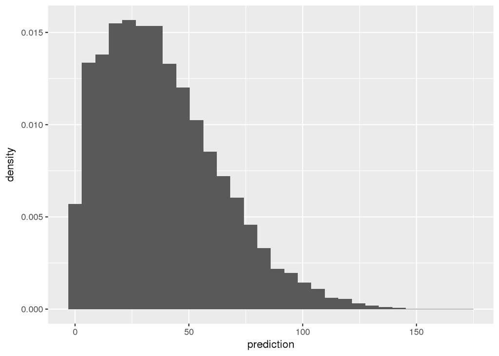

```r
simple_predict2 = data.frame(predictsimple2(4,8))
colnames(simple_predict2)[1]<- "prediction"

ggplot(simple_predict2, aes(x=prediction)) + geom_histogram(aes(y=..density..))
```

## Third model to predict points scored by a team using their rush yards/att and pass yards/att in the given game. Adjustment to Pois dist for non-negative points, attempt at log-normal model used in literature.

```r
simple3 <- "model{
  #Data
  for(i in 1:length(y)) {
        y[i] ~ dpois(lam[i])
        log(lam[i]) <-b0+b1*x[i]+b2*w[i]


   }

  #Priors
  b0 ~ dnorm(0,1/10)
  b1 ~ dnorm(1,1/10)
  b2 ~ dnorm(1,1/10)
  tau ~ dgamma(1,1/10)


}"


simple3_jags <- jags.model(textConnection(simple3),
                    data= list(y=data_2016$`Home_Points`, x=data_2016$`Home_Avg Rush Gain`, w=data_2016$`Home_Pass Gain/Att`),
                    inits=list(.RNG.name="base::Wichmann-Hill", .RNG.seed=1989))
simple3_sim <- coda.samples(simple3_jags, variable.names=c("b0","b1","b2","tau"), n.iter=10000)

simple3_sample <- data.frame(step=1:10000, simple3_sim[[1]])
head(simple3_sample)
```

```
##   step       b0         b1        b2        tau
## 1    1 2.114536 0.06378231 0.1129822  2.7301579
## 2    2 2.103755 0.06232092 0.1134889 16.6961555
## 3    3 2.116818 0.06011905 0.1143319 18.4016166
## 4    4 2.098308 0.05883514 0.1149738  3.5305963
## 5    5 2.101707 0.05926277 0.1139331 15.9334032
## 6    6 2.100882 0.05849072 0.1146099  0.6882222
```

```r
summary(simple3_sim)
```

```
##
## Iterations = 1001:11000
## Thinning interval = 1
## Number of chains = 1
## Sample size per chain = 10000
##
## 1. Empirical mean and standard deviation for each variable,
##    plus standard error of the mean:
##
##         Mean        SD  Naive SE Time-series SE
## b0   2.12177  0.062504 6.250e-04      0.0050073
## b1   0.05209  0.008677 8.677e-05      0.0004342
## b2   0.11608  0.006571 6.571e-05      0.0004303
## tau 10.04231 10.010556 1.001e-01      0.1001056
##
## 2. Quantiles for each variable:
##
##        2.5%     25%     50%      75%    97.5%
## b0  2.00190 2.07852 2.12115  2.16369  2.24303
## b1  0.03418 0.04648 0.05212  0.05795  0.06876
## b2  0.10325 0.11155 0.11612  0.12065  0.12864
## tau 0.25574 2.85695 6.98604 13.97338 36.50216
```

[figure not shown]

```r
plot(simple3_sim)
```

```r
set.seed(1000)
predictsimple3 <- function(x,w){
  rate <- rnorm(10000, 2.12177 + 0.05209*x + 0.11608*w, 10.04231^{-1})
  rate<-rate[rate>0]
  prediction <- rpois(10000,rate)
}

head(predictsimple3(4,8))
```

```
## [1] 5 3 2 4 3 6
```

```r
mean(predictsimple3(4,8))
```

```
## [1] 3.2739
```

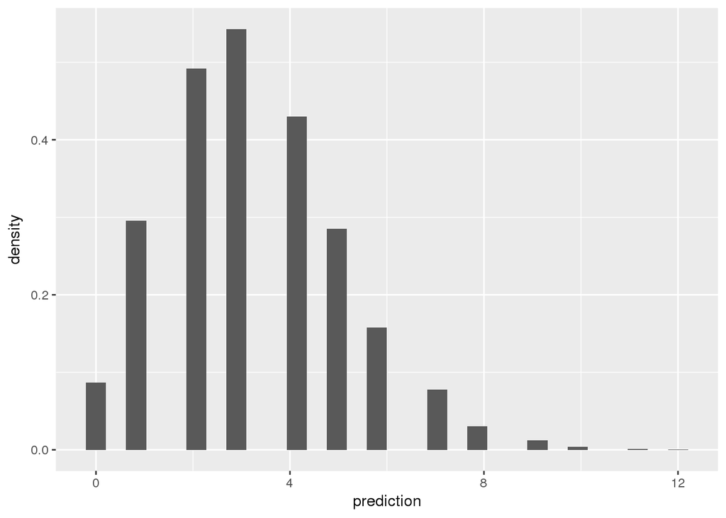

```r
simple_predict3 = data.frame(predictsimple3(4,8))
colnames(simple_predict3)[1]<- "prediction"

ggplot(simple_predict3, aes(x=prediction)) + geom_histogram(aes(y=..density..))
```